# Continuous Data Analysis Demo — The `t` Tests

Professor Christopher J. Schmank

2024-11-05

```r
# install.packages("datarium")
# install.packages("rstatix")
# install.packages("ggpubr")

library(jmv)
library(psych)
library(tidyverse)
library(infer)
library(datarium)
library(rstatix)
library(ggpubr)
```

## One-Sample `t`-test

One numerical variable

**Research Question 1**: Is the average weight of mice different from 25g? What about less than 25g?

```r
# Load and inspect demo data set(s)

# Load `mice` data from `datarium` package
data(mice, package="datarium")
head(mice)
```

```
## # A tibble: 6 × 2
##   name  weight
##   <chr>  <dbl>
## 1 M_1     18.9
## 2 M_2     19.5
## 3 M_3     23.1
## 4 M_4     20.1
## 5 M_5     20.3
## 6 M_6     23.4
```

**Hypothesis Statement**: 2-tailed (Non-directional)

$H_0$: Null Hypothesis — Average weight of sampled mice is not different from 25 g, $\mu_{sample} = \mu_{population} = \text{25 grams}$

$H_a$: Alternate Hypothesis — Average weight of sampled mice is different from 25 g, $\mu_{sample} \neq \mu_{population} \neq \text{25 grams}$

**Hypothesis Statement**: 1-tailed (Directional)

$H_0$: Null Hypothesis — Average weight of sampled mice is not less than 25 g, $\mu_{sample} \geq \mu_{population} \geq \text{25 grams}$

$H_a$: Alternate Hypothesis — Average weight of sampled mice is less than 25 g, $\mu_{sample} < \mu_{population} < \text{25 grams}$

**Research Question 2**: Is the average hours of work different from 40 hours per week? What about greater than 40 hours per week?

```r
set.seed(13)
# Load `gss` data from `infer` package
data(gss, package="infer")
gss <- gss %>%
  select(hours) %>%
  rep_sample_n(size = 100, replace = TRUE)
head(gss)
```

```
## # A tibble: 6 × 2
## # Groups:   replicate [1]
##   replicate hours
##       <int> <dbl>
## 1         1    40
## 2         1    64
## 3         1    70
## 4         1    55
## 5         1    50
## 6         1    48
```

**Hypothesis Statement**: 2-tailed (Non-directional)

$H_0$: Null Hypothesis — Average hours of work per week is not different from 40, $\mu_{sample} = \mu_{population} = \text{40 hours per week}$

$H_a$: Alternate Hypothesis — Average hours of work per week is different from 40, $\mu_{sample} \neq \mu_{population} \neq \text{40 hours per week}$

**Hypothesis Statement**: 1-tailed (Directional)

$H_0$: Null Hypothesis — Average hours of work per week is not greater than from 40, $\mu_{sample} \leq \mu_{population} \leq \text{40 hours per week}$

$H_a$: Alternate Hypothesis — Average hours of work per week is different from 40, $\mu_{sample} > \mu_{population} > \text{40 hours per week}$

## Descriptive Statistics (Do not forget to visualize!!)

```r
#Descriptive statistics for `weight` variable
describe(mice$weight)
```

```
##    vars  n  mean  sd median trimmed  mad  min  max range skew kurtosis  se
## X1    1 10 20.14 1.9   19.8   20.06 1.48 17.5 23.4   5.9 0.52    -1.08 0.6
```

```r
#Descriptive statistics for `hours` variable
describe(gss$hours)
```

```
##    vars   n  mean    sd median trimmed   mad min max range skew kurtosis   se
## X1    1 100 45.39 16.14   40.5   44.94 11.12   4  89    85 0.31     1.28 1.61
```

## `jmv` One-Sample `t`-test `ttestOneS()`

**Research Question 1**

```r
mice %>%
ttestOneS(vars=weight,
          testValue = 25,
          hypothesis = 'dt',
          norm = TRUE,
          ci = TRUE,
          effectSize = TRUE,
          ciES = TRUE,
          desc = TRUE)
```

```
##
##  ONE SAMPLE T-TEST
##
##  One Sample T-Test
##  ─────────────────────────────────────────────────────────────────────────────────────────────────────────────────────
##                             Statistic    df          p                         Effect Size    Lower        Upper
##  ─────────────────────────────────────────────────────────────────────────────────────────────────────────────────────
##    weight    Student's t    -8.104504    9.000000    0.0000200    Cohen's d      -2.562869    -3.866962    -1.230830
##  ─────────────────────────────────────────────────────────────────────────────────────────────────────────────────────
##    Note. Hₐ μ ≠ 25
##
##
##  Normality Test (Shapiro-Wilk)
##  ────────────────────────────────────
##              W            p
##  ────────────────────────────────────
##    weight    0.9229514    0.3822300
##  ────────────────────────────────────
##    Note. A low p-value suggests a
##    violation of the assumption of
##    normality
##
##
##  Descriptives
##  ─────────────────────────────────────────────────────────────────
##              N     Mean        Median      SD          SE
##  ─────────────────────────────────────────────────────────────────
##    weight    10    20.14000    19.80000    1.896312    0.5996666
##  ─────────────────────────────────────────────────────────────────
```

```r
mice %>%
ttestOneS(vars=weight,
          testValue = 25,
          hypothesis = 'lt',
          norm = TRUE,
          ci = TRUE,
          effectSize = TRUE,
          ciES = TRUE,
          desc = TRUE)
```

```
##
##  ONE SAMPLE T-TEST
##
##  One Sample T-Test
##  ─────────────────────────────────────────────────────────────────────────────────────────────────────────────────────
##                             Statistic    df          p                         Effect Size    Lower        Upper
##  ─────────────────────────────────────────────────────────────────────────────────────────────────────────────────────
##    weight    Student's t    -8.104504    9.000000    0.0000100    Cohen's d      -2.562869    -3.866962    -1.230830
##  ─────────────────────────────────────────────────────────────────────────────────────────────────────────────────────
##    Note. Hₐ μ < 25
##
##
##  Normality Test (Shapiro-Wilk)
##  ────────────────────────────────────
##              W            p
##  ────────────────────────────────────
##    weight    0.9229514    0.3822300
##  ────────────────────────────────────
##    Note. A low p-value suggests a
##    violation of the assumption of
##    normality
##
##
##  Descriptives
##  ─────────────────────────────────────────────────────────────────
##              N     Mean        Median      SD          SE
##  ─────────────────────────────────────────────────────────────────
##    weight    10    20.14000    19.80000    1.896312    0.5996666
##  ─────────────────────────────────────────────────────────────────
```

## Publishable Plot | Using `rstatix` and `ggpubr` packages

```r
stat_test <- mice %>% rstatix::t_test(weight ~ 1, mu = 25, alternative="two.sided")
stat_test
```

```
## # A tibble: 1 × 7
##   .y.    group1 group2         n statistic    df       p
## * <chr>  <chr>  <chr>      <int>     <dbl> <dbl>   <dbl>
## 1 weight 1      null model    10     -8.10     9 0.00002
```

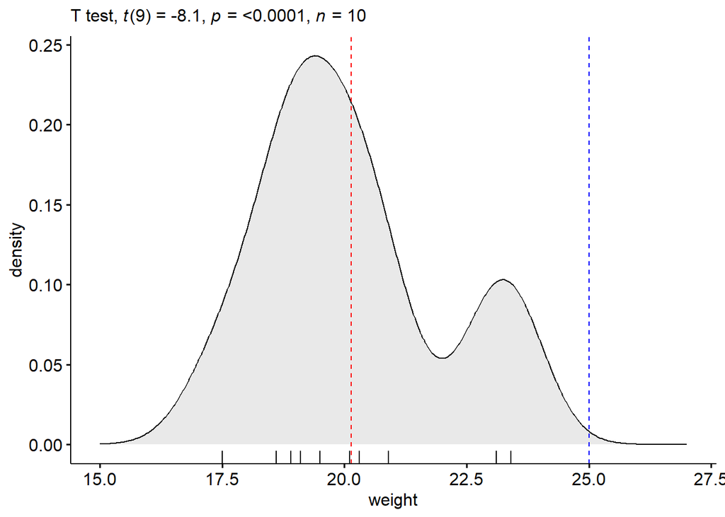

```r
# `alternative =` can be set to `greater` or `less` as well

# Density Plot

ggdensity(mice,
          x = "weight",
          rug = TRUE,
          fill = "lightgray") +
  scale_x_continuous(limits = c(15, 27)) +
  stat_central_tendency(type = "mean", color = "red", linetype = "dashed") +
  geom_vline(xintercept = 25, color = "blue", linetype = "dashed") +
  labs(subtitle = get_test_label(stat_test,  detailed = TRUE))
```

**Research Question 2**

```r
gss %>%
ttestOneS(vars=hours,
          testValue = 40,
          hypothesis = 'dt',
          norm = TRUE,
          ci = TRUE,
          effectSize = TRUE,
          ciES = TRUE,
          desc = TRUE)
```

```
##
##  ONE SAMPLE T-TEST
##
##  One Sample T-Test
##  ────────────────────────────────────────────────────────────────────────────────────────────────────────────────────
##                            Statistic    df          p                         Effect Size    Lower        Upper
##  ────────────────────────────────────────────────────────────────────────────────────────────────────────────────────
##    hours    Student's t     3.340155    99.00000    0.0011817    Cohen's d      0.3340155    0.1317878    0.5346448
##  ────────────────────────────────────────────────────────────────────────────────────────────────────────────────────
##    Note. Hₐ μ ≠ 40
##
##
##  Normality Test (Shapiro-Wilk)
##  ───────────────────────────────────
##             W            p
##  ───────────────────────────────────
##    hours    0.9154242    0.0000081
##  ───────────────────────────────────
##    Note. A low p-value suggests
##    a violation of the assumption
##    of normality
##
##
##  Descriptives
##  ────────────────────────────────────────────────────────────────
##             N      Mean        Median      SD          SE
##  ────────────────────────────────────────────────────────────────
##    hours    100    45.39000    40.50000    16.13697    1.613697
##  ────────────────────────────────────────────────────────────────
```

```r
gss %>%
ttestOneS(vars=hours,
          testValue = 40,
          hypothesis = 'gt',
          norm = TRUE,
          ci = TRUE,
          effectSize = TRUE,
          ciES = TRUE,
          desc = TRUE)
```

```
##
##  ONE SAMPLE T-TEST
##
##  One Sample T-Test
##  ────────────────────────────────────────────────────────────────────────────────────────────────────────────────────
##                            Statistic    df          p                         Effect Size    Lower        Upper
##  ────────────────────────────────────────────────────────────────────────────────────────────────────────────────────
##    hours    Student's t     3.340155    99.00000    0.0005908    Cohen's d      0.3340155    0.1317878    0.5346448
##  ────────────────────────────────────────────────────────────────────────────────────────────────────────────────────
##    Note. Hₐ μ > 40
##
##
##  Normality Test (Shapiro-Wilk)
##  ───────────────────────────────────
##             W            p
##  ───────────────────────────────────
##    hours    0.9154242    0.0000081
##  ───────────────────────────────────
##    Note. A low p-value suggests
##    a violation of the assumption
##    of normality
##
##
##  Descriptives
##  ────────────────────────────────────────────────────────────────
##             N      Mean        Median      SD          SE
##  ────────────────────────────────────────────────────────────────
##    hours    100    45.39000    40.50000    16.13697    1.613697
##  ────────────────────────────────────────────────────────────────
```

```r
# Violations of the Shapiro-Wilks test can set `wilcoxon = TRUE` argument
# gss %>%
# ttestOneS(vars=hours,
#           testValue = 40,
#           hypothesis = 'dt',
#           norm = TRUE,
#           ci = TRUE,
#           effectSize = TRUE,
#           ciES = TRUE,
#           desc = TRUE,
#           wilcoxon = TRUE)
#
# gss %>%
# ttestOneS(vars=hours,
#           testValue = 40,
#           hypothesis = 'gt',
#           norm = TRUE,
#           ci = TRUE,
#           effectSize = TRUE,
#           ciES = TRUE,
#           desc = TRUE,
#           wilcoxon = TRUE)
```

```r
stat_test <- gss %>% rstatix::t_test(hours ~ 1, mu = 40, alternative = "greater")
stat_test
```

```
## # A tibble: 1 × 8
##   replicate .y.   group1 group2         n statistic    df        p
## *     <int> <chr> <chr>  <chr>      <int>     <dbl> <dbl>    <dbl>
## 1         1 hours 1      null model   100      3.34    99 0.000591
```

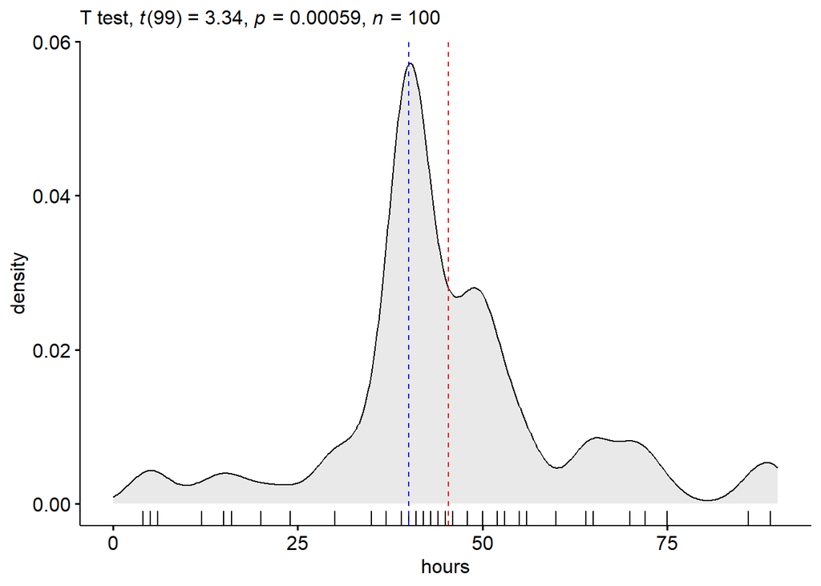

```r
# Density Plot

ggdensity(gss,
          x = "hours",
          rug = TRUE,
          fill = "lightgray") +
  scale_x_continuous(limits = c(0, 90)) +
  stat_central_tendency(type = "mean", color = "red", linetype = "dashed") +
  geom_vline(xintercept = 40, color = "blue", linetype = "dashed") +
  labs(subtitle = get_test_label(stat_test,  detailed = TRUE))
```

## APA Style Results Section

**Statistical Interpretation**:

## Paired-Sample (Repeated-Measure) `t`-test

Numerical variable collected twice OR `within-subject` DV

**Research Question 1**: Does the weight of 10 mice differ from `Before` to `After` following a prescribed treatment? Does the treatment lead to increased weight from `Before` to `After` for the 10 mice?

```r
# Load and inspect demo data set(s)

# Load `mice2` data from `datarium` package
data(mice2, package="datarium")
head(mice2)
```

```
##   id before after
## 1  1  187.2 429.5
## 2  2  194.2 404.4
## 3  3  231.7 405.6
## 4  4  200.5 397.2
## 5  5  201.7 377.9
## 6  6  235.0 445.8
```

```r
# Transform into long data:
# gather the before and after values in the same column
mice2_long <- mice2 %>%
  gather(key = "group", value = "weight", before, after)
head(mice2_long)
```

```
##   id  group weight
## 1  1 before  187.2
## 2  2 before  194.2
## 3  3 before  231.7
## 4  4 before  200.5
## 5  5 before  201.7
## 6  6 before  235.0
```

**Hypothesis Statement**: 2-tailed (Non-directional)

$H_0$: Null Hypothesis — Average weight of sampled mice is not different due to treatment (i.e., from `Before` to `After`), $\mu_{Before} = \mu_{After} \text{ OR } \mu_{Before - After} = 0$

$H_a$: Alternate Hypothesis — Average weight of sampled mice is different due to treatment (i.e., from `Before` to `After`), $\mu_{Before} \neq \mu_{After} \text{ OR } \mu_{Before - After} \neq 0$

**Hypothesis Statement**: 1-tailed (Directional)

$H_0$: Null Hypothesis — Average weight of sampled mice is not greater following treatment (i.e., from `Before` to `After`), $\mu_{Before} \geq \mu_{After} \text{ OR } \mu_{Before - After} \geq 0$

$H_a$: Alternate Hypothesis — Average weight of sampled mice is greater following treatment (i.e., from `Before` to `After`), $\mu_{Before} < \mu_{After} \text{ OR } \mu_{Before - After} < 0$

**Research Question 2**:

```r
# Load and inspect demo data set(s)

# Load `depression` data from `datarium` package
data(depression, package = "datarium")
depression<- depression %>%
  select(id,t0,t3)
head(depression)
```

```
## # A tibble: 6 × 3
##   id       t0    t3
##   <fct> <dbl> <dbl>
## 1 1       296   242
## 2 2       376   126
## 3 3       309   173
## 4 4       222   135
## 5 5       150   266
## 6 6       316   194
```

```r
# Transform into long data:
# gather the before and after values in the same column
dep_long <- depression %>%
  gather(key = "time_period", value = "depression", t0, t3)
head(dep_long)
```

```
## # A tibble: 6 × 3
##   id    time_period depression
##   <fct> <chr>            <dbl>
## 1 1     t0                 296
## 2 2     t0                 376
## 3 3     t0                 309
## 4 4     t0                 222
## 5 5     t0                 150
## 6 6     t0                 316
```

**Hypothesis Statement**: 2-tailed (Non-directional)

$H_0$: Null Hypothesis — Average depression level of sampled patients is not different from `Baseline` to `Follow-Up`, $\mu_{Baseline} = \mu_{Follow-Up} \text{ OR } \mu_{Baseline - Follow-Up} = 0$

$H_a$: Alternate Hypothesis — Average depression level of sampled patients is different from `Baseline` to `Follow-Up`, $\mu_{Baseline} \neq \mu_{Follow-Up} \text{ OR } \mu_{Baseline - Follow-Up} \neq 0$

**Hypothesis Statement**: 1-tailed (Directional)

$H_0$: Null Hypothesis — Average depression level of sampled patients is not lower from `Baseline` to `Follow-Up`, $\mu_{Baseline} \geq \mu_{Follow-Up} \text{OR } \mu_{Baseline - Follow-Up} \geq 0$

$H_a$: Alternate Hypothesis — Average depression level of sampled patients is lower from `Baseline` to `Follow-Up`, $\mu_{Baseline} < \mu_{Follow-Up} \text{OR } \mu_{Baseline - Follow-Up} < 0$

## Descriptive Statistics (Do not forget to visualize!!)

```r
# Change `group` into a factor
mice2_long$group<-factor(mice2_long$group)

# Use the `describeBy` function to isolate `weight`
describeBy(mice2_long[,3],group=mice2_long$group,mat=TRUE)
```

```
##     item group1 vars  n   mean       sd median trimmed      mad   min   max
## X11    1  after    1 10 400.04 30.08688 405.00 402.200 25.05594 337.0 445.8
## X12    2 before    1 10 200.56 20.02816 197.35 199.775 15.93795 172.4 235.0
##     range       skew  kurtosis       se
## X11 108.8 -0.5285935 -0.391983 9.514307
## X12  62.6  0.5132390 -1.077594 6.333460
```

```r
# Change `time_period` into a factor
dep_long$time_period<-factor(dep_long$time_period)

# Use the `describeBy` function to isolate `depression`
describeBy(dep_long[,3],group=dep_long$time_period,mat=TRUE)
```

```
##             item group1 vars  n     mean       sd median trimmed     mad min
## depression1    1     t0    1 24 292.3750 73.86757  309.5   295.3 41.5128 138
## depression2    2     t3    1 24 151.9167 78.02002  137.0   150.2 54.1149   6
##             max range       skew    kurtosis       se
## depression1 447   309 -0.4958564 -0.00301943 15.07816
## depression2 358   352  0.5007439  0.50394014 15.92577
```

## `jmv` Paired-Sample `t`-test `ttestPS()`

**Research Question 1**

```r
mice2 %>%
ttestPS(pairs=list(list(i1 = "before", i2 = "after")),
        hypothesis = 'different',
        norm = TRUE,
        ci = TRUE,
        effectSize = TRUE,
        ciES = TRUE,
        desc = TRUE)
```

```
##
##  PAIRED SAMPLES T-TEST
##
##  Paired Samples T-Test
##  ───────────────────────────────────────────────────────────────────────────────────────────────────────────────────────────────
##                                      statistic    df          p                          Effect Size    Lower        Upper
##  ───────────────────────────────────────────────────────────────────────────────────────────────────────────────────────────────
##    before    after    Student's t    -25.54630    9.000000    < .0000001    Cohen's d      -8.078449    -11.79143    -4.365761
##  ───────────────────────────────────────────────────────────────────────────────────────────────────────────────────────────────
##    Note. Hₐ μ <sub>Measure 1 - Measure 2</sub> ≠ 0
##
##
##  Normality Test (Shapiro-Wilk)
##  ──────────────────────────────────────────────────
##                            W            p
##  ──────────────────────────────────────────────────
##    before    -    after    0.9675122    0.8668697
##  ──────────────────────────────────────────────────
##    Note. A low p-value suggests a violation of
##    the assumption of normality
##
##
##  Descriptives
##  ────────────────────────────────────────────────────────────────
##              N     Mean        Median      SD          SE
##  ────────────────────────────────────────────────────────────────
##    before    10    200.5600    197.3500    20.02816    6.333460
##    after     10    400.0400    405.0000    30.08688    9.514307
##  ────────────────────────────────────────────────────────────────
```

```r
mice2 %>%
ttestPS(pairs=list(list(i1 = "before", i2 = "after")),
        hypothesis = 'twoGreater',
        norm = TRUE,
        ci = TRUE,
        effectSize = TRUE,
        ciES = TRUE,
        desc = TRUE)
```

```
##
##  PAIRED SAMPLES T-TEST
##
##  Paired Samples T-Test
##  ───────────────────────────────────────────────────────────────────────────────────────────────────────────────────────────────
##                                      statistic    df          p                          Effect Size    Lower        Upper
##  ───────────────────────────────────────────────────────────────────────────────────────────────────────────────────────────────
##    before    after    Student's t    -25.54630    9.000000    < .0000001    Cohen's d      -8.078449    -11.79143    -4.365761
##  ───────────────────────────────────────────────────────────────────────────────────────────────────────────────────────────────
##    Note. Hₐ μ <sub>Measure 1 - Measure 2</sub> < 0
##
##
##  Normality Test (Shapiro-Wilk)
##  ──────────────────────────────────────────────────
##                            W            p
##  ──────────────────────────────────────────────────
##    before    -    after    0.9675122    0.8668697
##  ──────────────────────────────────────────────────
##    Note. A low p-value suggests a violation of
##    the assumption of normality
##
##
##  Descriptives
##  ────────────────────────────────────────────────────────────────
##              N     Mean        Median      SD          SE
##  ────────────────────────────────────────────────────────────────
##    before    10    200.5600    197.3500    20.02816    6.333460
##    after     10    400.0400    405.0000    30.08688    9.514307
##  ────────────────────────────────────────────────────────────────
```

## Publishable Plot | Using `rstatix` and `ggpubr` packages

```r
stat_test <- mice2_long  %>%
  rstatix::t_test(weight ~ group, ref.group = "before", paired = TRUE, alternative = "two.sided") %>%
  add_significance()
stat_test
```

```
## # A tibble: 1 × 9
##   .y.    group1 group2    n1    n2 statistic    df             p p.signif
##   <chr>  <chr>  <chr>  <int> <int>     <dbl> <dbl>         <dbl> <chr>
## 1 weight before after     10    10     -25.5     9 0.00000000104 ****
```

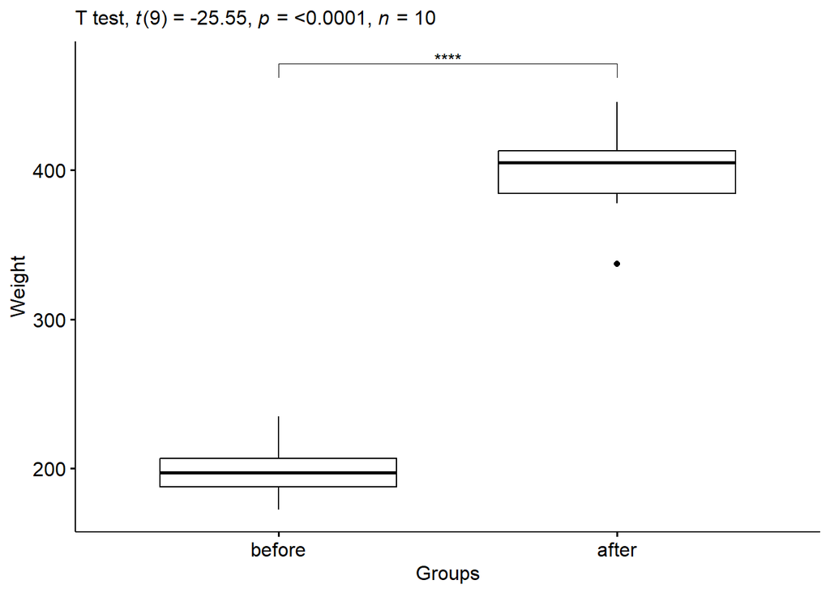

```r
# `alternative =` can be set to `greater` or `less` as well

# Side-by-Side Boxplot Comparison

# Create a box plot
bxp <- ggboxplot(mice2_long,
                x = "group",
                y = "weight",
                order = c("before", "after"),
                ylab = "Weight", xlab = "Groups")

# Add p-value and significance levels
stat_test <- stat_test %>% add_xy_position(x = "group")

bxp +
  stat_pvalue_manual(stat_test, tip.length = .03) +
  labs(subtitle = get_test_label(stat_test, detailed= TRUE))
```

**Research Quesiton 2**

```r
depression %>%
ttestPS(pairs=list(list(i1 = "t0", i2 = "t3")),
        hypothesis = 'different',
        norm = TRUE,
        ci = TRUE,
        effectSize = TRUE,
        ciES = TRUE,
        desc = TRUE)
```

```
##
##  PAIRED SAMPLES T-TEST
##
##  Paired Samples T-Test
##  ──────────────────────────────────────────────────────────────────────────────────────────────────────────────────────
##                               statistic    df          p                         Effect Size    Lower        Upper
##  ──────────────────────────────────────────────────────────────────────────────────────────────────────────────────────
##    t0    t3    Student's t     6.690499    23.00000    0.0000008    Cohen's d       1.365692    0.7976682    1.918325
##  ──────────────────────────────────────────────────────────────────────────────────────────────────────────────────────
##    Note. Hₐ μ <sub>Measure 1 - Measure 2</sub> ≠ 0
##
##
##  Normality Test (Shapiro-Wilk)
##  ───────────────────────────────────────────
##                     W            p
##  ───────────────────────────────────────────
##    t0    -    t3    0.9624806    0.4902547
##  ───────────────────────────────────────────
##    Note. A low p-value suggests a
##    violation of the assumption of
##    normality
##
##
##  Descriptives
##  ────────────────────────────────────────────────────────────
##          N     Mean        Median      SD          SE
##  ────────────────────────────────────────────────────────────
##    t0    24    292.3750    309.5000    73.86757    15.07816
##    t3    24    151.9167    137.0000    78.02002    15.92577
##  ────────────────────────────────────────────────────────────
```

```r
depression %>%
ttestPS(pairs=list(list(i1 = "t0", i2 = "t3")),
        hypothesis = 'oneGreater',
        norm = TRUE,
        ci = TRUE,
        effectSize = TRUE,
        ciES = TRUE,
        desc = TRUE)
```

```
##
##  PAIRED SAMPLES T-TEST
##
##  Paired Samples T-Test
##  ──────────────────────────────────────────────────────────────────────────────────────────────────────────────────────
##                               statistic    df          p                         Effect Size    Lower        Upper
##  ──────────────────────────────────────────────────────────────────────────────────────────────────────────────────────
##    t0    t3    Student's t     6.690499    23.00000    0.0000004    Cohen's d       1.365692    0.7976682    1.918325
##  ──────────────────────────────────────────────────────────────────────────────────────────────────────────────────────
##    Note. Hₐ μ <sub>Measure 1 - Measure 2</sub> > 0
##
##
##  Normality Test (Shapiro-Wilk)
##  ───────────────────────────────────────────
##                     W            p
##  ───────────────────────────────────────────
##    t0    -    t3    0.9624806    0.4902547
##  ───────────────────────────────────────────
##    Note. A low p-value suggests a
##    violation of the assumption of
##    normality
##
##
##  Descriptives
##  ────────────────────────────────────────────────────────────
##          N     Mean        Median      SD          SE
##  ────────────────────────────────────────────────────────────
##    t0    24    292.3750    309.5000    73.86757    15.07816
##    t3    24    151.9167    137.0000    78.02002    15.92577
##  ────────────────────────────────────────────────────────────
```

```r
stat_test <- dep_long  %>%
  rstatix::t_test(depression ~ time_period, paired = TRUE, ref.group = "t0", alternative = "greater") %>%
  add_significance()
stat_test
```

```
## # A tibble: 1 × 9
##   .y.        group1 group2    n1    n2 statistic    df           p p.signif
##   <chr>      <chr>  <chr>  <int> <int>     <dbl> <dbl>       <dbl> <chr>
## 1 depression t0     t3        24    24      6.69    23 0.000000398 ****
```

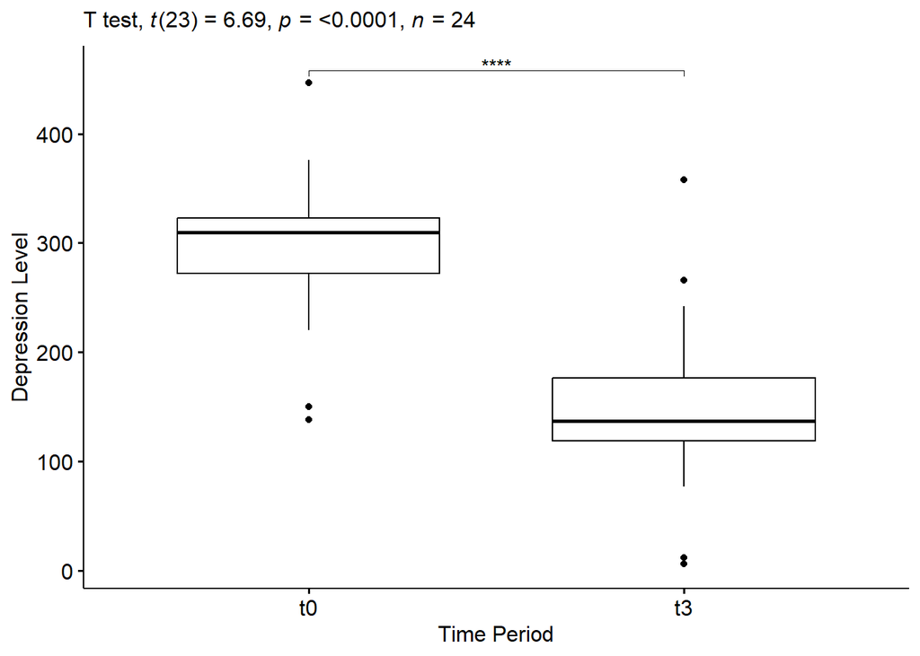

```r
# `alternative =` can be set to `greater` or `less` as well

# Side-by-Side Boxplot Comparison

# Create a box plot
bxp <- ggboxplot(dep_long,
                x = "time_period",
                y = "depression",
                order = c("t0", "t3"),
                ylab = "Depression Level", xlab = "Time Period")

# Add p-value and significance levels
stat_test <- stat_test %>% add_xy_position(x = "time_period")

bxp +
  stat_pvalue_manual(stat_test, tip.length = 0.01) +
  labs(subtitle = get_test_label(stat_test, detailed= TRUE))
```

## APA Style Results Section

**Statistical Interpretation**:

A paired-sample *t*-test was conducted to determine whether there was a difference between the depression level among our sample from baseline (`t0`) to a 6 month follow-up (`t3`). The results indicated that depression level at baseline (*M* = 292.38, *SD* = 73.87) was statistically significantly higher than depression level at 6 month follow-up (*M* = 151.92, *SD* = 78.02), *t*(23) = 6.69, *p* < .001, Cohen’s *d* = 1.37, 95% CI [.798, 1.918].

## Independent-Samples (Between-Subject) `t`-test

Numerical DV; Mutually Exclusive, Binary Grouping Variable

**Research Question 1**: Does the average stress level of 60 participants differ due to a randomly assigned stress treatment ($n_{perGroup} = 30$)? Was the average stress level of the `treatment group` lower than the average stress level of the `non-treatment group`?

```r
# Load and inspect demo data set(s)

# Load `mice2` data from `datarium` package
data(stress, package="datarium")
stress <- stress %>%
  select(id,score,treatment)
head(stress)
```

```
## # A tibble: 6 × 3
##      id score treatment
##   <int> <dbl> <fct>
## 1     1  95.6 yes
## 2     2  82.2 yes
## 3     3  97.2 yes
## 4     4  96.4 yes
## 5     5  81.4 yes
## 6     6  83.6 yes
```

**Hypothesis Statement**: 2-tailed (Non-directional)

$H_0$: Null Hypothesis — Average stress level was not different between treatment groups (i.e., from `Treatment` to `Non-treatment`), $\mu_{Treatment} = \mu_{Non-Treatment} \text{ OR } \mu_{Treatment } - \mu_{Non-Treatment} = 0$

$H_a$: Alternate Hypothesis — Average stress level was different between treatment groups (i.e., from `Treatment` to `Non-treatment`), $\mu_{Treatment} \neq \mu_{Non-Treatment} \text{ OR } \mu_{Treatment } - \mu_{Non-Treatment} \neq 0$

**Hypothesis Statement**: 1-tailed (Directional)

$H_0$: Null Hypothesis — Average stress level was not lower between the `treatment` and `non-treatment` groups, $\mu_{Treatment} \geq \mu_{Non-Treatment} \text{ OR } \mu_{Treatment } - \mu_{Non-Treatment} \geq 0$

$H_a$: Alternate Hypothesis — Average stress level was lower between the `treatment` and `non-treatment` groups, $\mu_{Treatment} < \mu_{Non-Treatment} \text{ OR } \mu_{Treatment } - \mu_{Non-Treatment} < 0$

**Research Question 2**: Does the average increase in hours of sleep across 20 participants differ due to a randomly assigned treatment ($n_{perGroup} = 10$)? Was the average increase in hours of sleep of the `medication group` greater than the average increase in hours of sleep of the `Control group`?

```r
# Load and inspect demo data set(s)

# Load `depression` data from `datarium` package
data(sleep, package = "datasets")
head(sleep)
```

```
##   extra group ID
## 1   0.7     1  1
## 2  -1.6     1  2
## 3  -0.2     1  3
## 4  -1.2     1  4
## 5  -0.1     1  5
## 6   3.4     1  6
```

**Hypothesis Statement**: 2-tailed (Non-directional)

$H_0$: Null Hypothesis — Average increases in hours of sleep was not different between treatment groups (i.e., from `Medication` to `Control`), $\mu_{Medication} = \mu_{Control} \text{ OR } \mu_{Medication } - \mu_{Control} = 0$

$H_a$: Alternate Hypothesis — Average increases in hours of sleep was different between treatment groups (i.e., from `Medication` to `Control`), $\mu_{Medication} \neq \mu_{Control} \text{ OR } \mu_{Medication } - \mu_{Control} \neq 0$

**Hypothesis Statement**: 1-tailed (Directional)

$H_0$: Null Hypothesis — Average increases in hours of sleep was not greater from `Medication` to `Control Treatment Groups`, $\mu_{Medication} \leq \mu_{Control} \text{ OR } \mu_{Medication } - \mu_{Control} \leq 0$

$H_a$: Alternate Hypothesis — Average increases in hours of sleep was greater from `Medication` to `Control Treatment Groups`, $\mu_{Medication} > \mu_{Control} \text{ OR } \mu_{Medication } - \mu_{Control} > 0$

## Descriptive Statistics (Do not forget to visualize!!)

```r
# Use the `describeBy` function
describeBy(stress$score,group=stress$treatment,mat=TRUE)
```

```
##     item group1 vars  n     mean       sd median  trimmed     mad  min   max
## X11    1    yes    1 30 82.15667 9.161527  83.45 82.08750 9.11799 65.8  97.2
## X12    2     no    1 30 86.99667 6.166678  87.30 87.18333 7.11648 75.3 100.0
##     range        skew   kurtosis       se
## X11  31.4 -0.05540563 -1.1109814 1.672658
## X12  24.7 -0.14771494 -0.6624365 1.125876
```

```r
describeBy(sleep$extra,group=sleep$group,mat=TRUE)
```

```
##     item group1 vars  n mean       sd median trimmed     mad  min max range
## X11    1      1    1 10 0.75 1.789010   0.35  0.6750 1.55673 -1.6 3.7   5.3
## X12    2      2    1 10 2.33 2.002249   1.75  2.2375 2.44629 -0.1 5.5   5.6
##          skew  kurtosis        se
## X11 0.4182629 -1.300391 0.5657345
## X12 0.2777800 -1.662971 0.6331666
```

## `jmv` Independent-Samples `t`-test `ttestIS()`

**Research Question 1**

```r
stress %>%
ttestIS(vars= "score",
        group = "treatment",
        hypothesis = 'different',
        norm = TRUE,
        eqv = TRUE,
        ci = TRUE,
        effectSize = TRUE,
        ciES = TRUE,
        desc = TRUE)
```

```
##
##  INDEPENDENT SAMPLES T-TEST
##
##  Independent Samples T-Test
##  ────────────────────────────────────────────────────────────────────────────────────────────────────────────────────────
##                            Statistic      df          p                         Effect Size    Lower        Upper
##  ────────────────────────────────────────────────────────────────────────────────────────────────────────────────────────
##    score    Student's t    -2.400461 ᵃ    58.00000    0.0196037    Cohen's d     -0.6197963    -1.135676    -0.09882660
##  ────────────────────────────────────────────────────────────────────────────────────────────────────────────────────────
##    Note. Hₐ μ <sub>yes</sub> ≠ μ <sub>no</sub>
##    ᵃ Levene's test is significant (p < .05), suggesting a violation of the assumption of equal variances
##
##
##  ASSUMPTIONS
##
##  Normality Test (Shapiro-Wilk)
##  ───────────────────────────────────
##             W            p
##  ───────────────────────────────────
##    score    0.9765152    0.2993356
##  ───────────────────────────────────
##    Note. A low p-value suggests
##    a violation of the assumption
##    of normality
##
##
##  Homogeneity of Variances Test (Levene's)
##  ───────────────────────────────────────────────
##             F           df    df2    p
##  ───────────────────────────────────────────────
##    score    4.791391     1     58    0.0326413
##  ───────────────────────────────────────────────
##    Note. A low p-value suggests a violation
##    of the assumption of equal variances
##
##
##  Group Descriptives
##  ────────────────────────────────────────────────────────────────────────
##             Group    N     Mean        Median      SD          SE
##  ────────────────────────────────────────────────────────────────────────
##    score    yes      30    82.15667    83.45000    9.161527    1.672658
##             no       30    86.99667    87.30000    6.166678    1.125876
##  ────────────────────────────────────────────────────────────────────────
```

```r
stress %>%
ttestIS(vars= "score",
        group = "treatment",
        hypothesis = 'twoGreater',
        norm = TRUE,
        eqv = TRUE,
        ci = TRUE,
        effectSize = TRUE,
        ciES = TRUE,
        desc = TRUE)
```

```
##
##  INDEPENDENT SAMPLES T-TEST
##
##  Independent Samples T-Test
##  ────────────────────────────────────────────────────────────────────────────────────────────────────────────────────────
##                            Statistic      df          p                         Effect Size    Lower        Upper
##  ────────────────────────────────────────────────────────────────────────────────────────────────────────────────────────
##    score    Student's t    -2.400461 ᵃ    58.00000    0.0098018    Cohen's d     -0.6197963    -1.135676    -0.09882660
##  ────────────────────────────────────────────────────────────────────────────────────────────────────────────────────────
##    Note. Hₐ μ <sub>yes</sub> < μ <sub>no</sub>
##    ᵃ Levene's test is significant (p < .05), suggesting a violation of the assumption of equal variances
##
##
##  ASSUMPTIONS
##
##  Normality Test (Shapiro-Wilk)
##  ───────────────────────────────────
##             W            p
##  ───────────────────────────────────
##    score    0.9765152    0.2993356
##  ───────────────────────────────────
##    Note. A low p-value suggests
##    a violation of the assumption
##    of normality
##
##
##  Homogeneity of Variances Test (Levene's)
##  ───────────────────────────────────────────────
##             F           df    df2    p
##  ───────────────────────────────────────────────
##    score    4.791391     1     58    0.0326413
##  ───────────────────────────────────────────────
##    Note. A low p-value suggests a violation
##    of the assumption of equal variances
##
##
##  Group Descriptives
##  ────────────────────────────────────────────────────────────────────────
##             Group    N     Mean        Median      SD          SE
##  ────────────────────────────────────────────────────────────────────────
##    score    yes      30    82.15667    83.45000    9.161527    1.672658
##             no       30    86.99667    87.30000    6.166678    1.125876
##  ────────────────────────────────────────────────────────────────────────
```

```r
# Violations of the Levenes test can set `welchs = TRUE` argument
# stress %>%
# ttestIS(vars= "score",
#         group = "treatment",
#         hypothesis = 'different',
#         norm = TRUE,
#         eqv = TRUE,
#         ci = TRUE,
#         effectSize = TRUE,
#         ciES = TRUE,
#         desc = TRUE,
#         welchs = TRUE)
#
# stress %>%
# ttestIS(vars= "score",
#         group = "treatment",
#         hypothesis = 'twoGreater',
#         norm = TRUE,
#         eqv = TRUE,
#         ci = TRUE,
#         effectSize = TRUE,
#         ciES = TRUE,
#         desc = TRUE,
#         welchs = TRUE)
```

## Publishable Plot | Using `rstatix` and `ggpubr` packages

```r
stat_test <- stress  %>%
  rstatix::t_test(score ~ treatment, ref.group = "yes", alternative = "two.sided", var.equal = TRUE) %>%
  add_significance()
stat_test
```

```
## # A tibble: 1 × 9
##   .y.   group1 group2    n1    n2 statistic    df      p p.signif
##   <chr> <chr>  <chr>  <int> <int>     <dbl> <dbl>  <dbl> <chr>
## 1 score yes    no        30    30     -2.40    58 0.0196 *
```

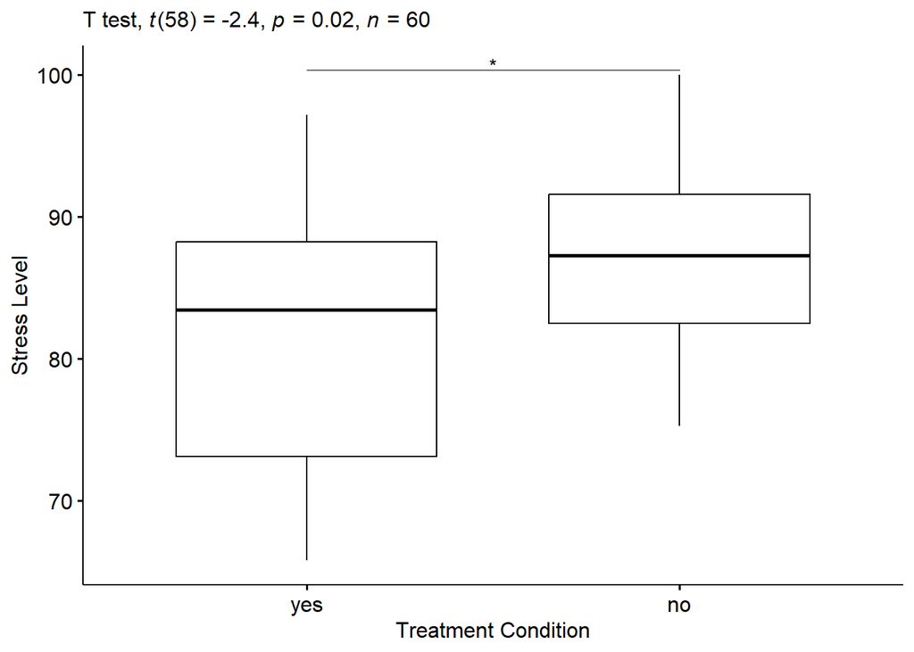

```r
# `alternative =` can be set to `greater` or `less` as well

# Side-by-Side Boxplot Comparison

# Create a box plot
bxp <- ggboxplot(stress,
                x = "treatment",
                y = "score",
                order = c("yes", "no"),
                ylab = "Stress Level", xlab = "Treatment Condition")

# Add p-value and significance levels
stat_test <- stat_test %>% add_xy_position(x = "treatment")

bxp +
  stat_pvalue_manual(stat_test, tip.length = 0) +
  labs(subtitle = get_test_label(stat_test, detailed= TRUE))
```

**Research Question 2**

```r
sleep %>%
ttestIS(vars= "extra",
        group = "group",
        hypothesis = 'different',
        norm = TRUE,
        eqv = TRUE,
        ci = TRUE,
        effectSize = TRUE,
        ciES = TRUE,
        desc = TRUE)
```

```
##
##  INDEPENDENT SAMPLES T-TEST
##
##  Independent Samples T-Test
##  ─────────────────────────────────────────────────────────────────────────────────────────────────────────────────────
##                            Statistic    df          p                         Effect Size    Lower        Upper
##  ─────────────────────────────────────────────────────────────────────────────────────────────────────────────────────
##    extra    Student's t    -1.860813    18.00000    0.0791867    Cohen's d     -0.8321811    -1.738817    0.09545948
##  ─────────────────────────────────────────────────────────────────────────────────────────────────────────────────────
##    Note. Hₐ μ <sub>1</sub> ≠ μ <sub>2</sub>
##
##
##  ASSUMPTIONS
##
##  Normality Test (Shapiro-Wilk)
##  ───────────────────────────────────
##             W            p
##  ───────────────────────────────────
##    extra    0.9194900    0.0968711
##  ───────────────────────────────────
##    Note. A low p-value suggests
##    a violation of the assumption
##    of normality
##
##
##  Homogeneity of Variances Test (Levene's)
##  ────────────────────────────────────────────────
##             F            df    df2    p
##  ────────────────────────────────────────────────
##    extra    0.6197235     1     18    0.4413931
##  ────────────────────────────────────────────────
##    Note. A low p-value suggests a violation
##    of the assumption of equal variances
##
##
##  Group Descriptives
##  ───────────────────────────────────────────────────────────────────────────
##             Group    N     Mean         Median       SD          SE
##  ───────────────────────────────────────────────────────────────────────────
##    extra    1        10    0.7500000    0.3500000    1.789010    0.5657345
##             2        10     2.330000     1.750000    2.002249    0.6331666
##  ───────────────────────────────────────────────────────────────────────────
```

```r
sleep %>%
ttestIS(vars= "extra",
        group = "group",
        hypothesis = 'twoGreater',
        norm = TRUE,
        eqv = TRUE,
        ci = TRUE,
        effectSize = TRUE,
        ciES = TRUE,
        desc = TRUE)
```

```
##
##  INDEPENDENT SAMPLES T-TEST
##
##  Independent Samples T-Test
##  ─────────────────────────────────────────────────────────────────────────────────────────────────────────────────────
##                            Statistic    df          p                         Effect Size    Lower        Upper
##  ─────────────────────────────────────────────────────────────────────────────────────────────────────────────────────
##    extra    Student's t    -1.860813    18.00000    0.0395934    Cohen's d     -0.8321811    -1.738817    0.09545948
##  ─────────────────────────────────────────────────────────────────────────────────────────────────────────────────────
##    Note. Hₐ μ <sub>1</sub> < μ <sub>2</sub>
##
##
##  ASSUMPTIONS
##
##  Normality Test (Shapiro-Wilk)
##  ───────────────────────────────────
##             W            p
##  ───────────────────────────────────
##    extra    0.9194900    0.0968711
##  ───────────────────────────────────
##    Note. A low p-value suggests
##    a violation of the assumption
##    of normality
##
##
##  Homogeneity of Variances Test (Levene's)
##  ────────────────────────────────────────────────
##             F            df    df2    p
##  ────────────────────────────────────────────────
##    extra    0.6197235     1     18    0.4413931
##  ────────────────────────────────────────────────
##    Note. A low p-value suggests a violation
##    of the assumption of equal variances
##
##
##  Group Descriptives
##  ───────────────────────────────────────────────────────────────────────────
##             Group    N     Mean         Median       SD          SE
##  ───────────────────────────────────────────────────────────────────────────
##    extra    1        10    0.7500000    0.3500000    1.789010    0.5657345
##             2        10     2.330000     1.750000    2.002249    0.6331666
##  ───────────────────────────────────────────────────────────────────────────
```

```r
stat_test <- sleep  %>%
  rstatix::t_test(extra ~ group, ref.group = "1", alternative = "less", var.equal = TRUE) %>%
  add_significance()
stat_test
```

```
## # A tibble: 1 × 9
##   .y.   group1 group2    n1    n2 statistic    df      p p.signif
##   <chr> <chr>  <chr>  <int> <int>     <dbl> <dbl>  <dbl> <chr>
## 1 extra 1      2         10    10     -1.86    18 0.0396 *
```

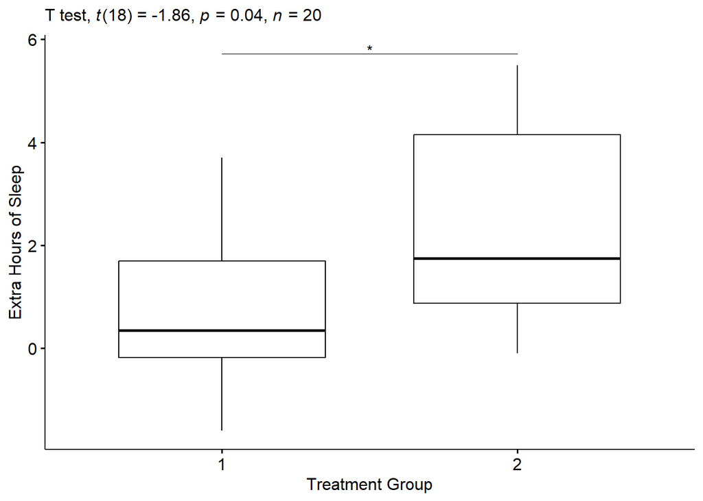

```r
# `alternative =` can be set to `greater` or `less` as well

# Side-by-Side Boxplot Comparison

# Create a box plot
bxp <- ggboxplot(sleep,
                x = "group",
                y = "extra",
                order = c("1", "2"),
                ylab = "Extra Hours of Sleep", xlab = "Treatment Group")

# Add p-value and significance levels
stat_test <- stat_test %>% add_xy_position(x = "group")

bxp +
  stat_pvalue_manual(stat_test, tip.length = 0) +
  labs(subtitle = get_test_label(stat_test, detailed= TRUE))
```

## APA Style Results Section

**Statistical Interpretation**: